# Projektseite

Die Temperaturschichtung im See selbst messen und verstehen

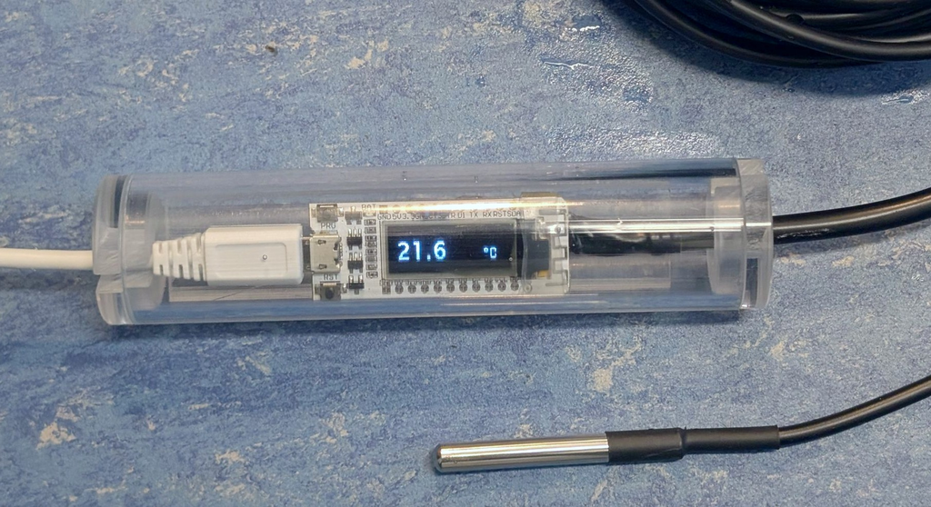

Eine Do-It-Yourself (DIY)-Sonde zur Erfassung der thermischen Schichtung von Seen

Dieses Repository enthält ergänzendes Material zum Bauvorschlag “Temperatursonde für Seen” für den Zeitschriftenartikel in “Unterricht Biologie kompakt”. Das Repository beschränkt sich auf die technischen Aspekte. Die fachlichen Hintergründe, didaktischen Empfehlungen und Arbeitsaufgaben finden Sie im Zeitschriftenartikel (in Vorbereitung).

## 1 Bauanleitung, Programmcode und Beispieldatensatz

- [**Detaillierte Bauanleitung**](https://tpetzoldt.github.io/seetemperatur/bauanleitung.html)
- Code für einen [Temperatursensor mit Display](https://github.com/tpetzoldt/seetemperatur/tree/main/code/t-sensor-display/) (Arduino-Sketch)
- Beispieldatensatz: [Temperaturmessungen im Versuchsteich](https://github.com/tpetzoldt/seetemperatur/raw/refs/heads/main/daten/versuchsteich-jun2023-10min.xlsx) (versuchsteich-jun2023-10min.xlsx)

## 2 Lizenz

- Dokumente, Daten, Programmcode und Fotos in diesem Web-Repository dienen zur Ergänzung des Zeitschriftenbeitrags. Sie können im Unterschied zum gedruckten Heft entsprechend der Creative Commons Lizenz CC-BY 4.0 frei genutzt werden.
- Im Interesse der Kompatibilität der Codebeispiele mit GPL-lizensiertem Code stehen die Inhalte zusätzlich unter einer Dual-Lizenz. Sie können frei entscheiden ob Sie die [GPL 2.0](https://www.gnu.de/documents/gpl-2.0.de.html), die [GPL 3.0](https://www.gnu.de/documents/gpl-3.0.de.html) oder die permissivere [CC-BY 4.0](https://creativecommons.org/licenses/by/4.0/deed.de) anwenden möchten.
- In der Praxis erlauben alle genannten Lizenzen eine freie Nutzung unter fairen Bedingungen und erfordern eine Quellenangabe.
- Für die im gedruckten Zeitschriftenartikel enthaltenen Texte und Abbildungen gilt im Unterschied dazu das Copyright des [Friedrich Verlags](https://www.friedrich-verlag.de/).

## 3 Weblinks und Literatur

### 3.1 Didaktisches Material

- Unterricht Biologie kompakt (2026). Ökosystem See – Gleichgewicht auf der Kippe. Friedrich Verlag, Hannover, 50. Jahrgang, April 2026, ISSN 0341-5260, https://t1p.de/ql662

### 3.2 Mikrocontroller-Programmierung

- Arduino-Programmierungebung: https://www.arduino.cc/

### 3.3 Forschungsprojekte

Das vom Bundesministerium für Forschung, Technologie und Raumfahrt geförderte Projekt “Klimakonform” beschäftigt sich mit den Auswirkungen der Klimaerwärmung und mit Möglichkeiten zur Klimaanpassung. In diesem Zusammenhang sind sogenannte Faktenblätter mit Hintergrundinformationen zur Schichtung in Talsperren und zur Trinkwasserversorgung entstanden. Mehr dazu unter:

- https://klimakonform.uw.tu-dresden.de/ (Projektseite)
- Faktenblatt Talsperren: Schichtung [pdf 0,3 MB](https://klimakonform.uw.tu-dresden.de/images/pdf/klimakonform_faktenblatt_talsperren_01_schichtung.pdf)
- Faktenblatt Talsperren: Klimawandel [pdf 0,6 MB](https://klimakonform.uw.tu-dresden.de/images/pdf/klimakonform_faktenblatt_talsperren_02_klimatrend.pdf)
- Faktenblatt Talsperre: Bewirtschaftung [pdf 0,4 MB](https://klimakonform.uw.tu-dresden.de/images/pdf/klimakonform_faktenblatt_talsperren_03_management.pdf)

**Homepage des Autors**

- https://tu-dresden.de/Members/thomas.petzoldt

Stand 2026-05-17